# PA 9.1

Author

Pete Woo

## The Data

At this link, you will find a dataset containing information about heart disease patients: https://www.dropbox.com/scl/fi/0vrpdnq5asmeulc4gd50y/ha_1.csv?rlkey=ciisalceotl77ffqhqe3kujzv&dl=1

A description of the original dataset can be found here: https://archive.ics.uci.edu/dataset/45/heart+disease (However, this dataset has been cleaned and reduced, and the people have been given fictious names.)

```python
import pandas as pd
import numpy as np
from sklearn.pipeline import Pipeline
from sklearn.neighbors import KNeighborsClassifier
from sklearn.tree import DecisionTreeClassifier
from sklearn.linear_model import LogisticRegression
from sklearn.model_selection import GridSearchCV


from sklearn.compose import make_column_selector, ColumnTransformer
from sklearn.preprocessing import StandardScaler, OneHotEncoder, PolynomialFeatures
```

```python
df = pd.read_csv("https://www.dropbox.com/scl/fi/0vrpdnq5asmeulc4gd50y/ha_1.csv?rlkey=ciisalceotl77ffqhqe3kujzv&dl=1")

df.head()
```

|  | Name | age | sex | cp | trtbps | chol | restecg | thalach | diagnosis |
| --- | --- | --- | --- | --- | --- | --- | --- | --- | --- |
| 0 | Magnolia Cassin | 60 | 1 | 1 | 117 | 230 | 1 | 160 | No Disease |
| 1 | Dr. Cathern Heathcote | 60 | 0 | 3 | 102 | 318 | 1 | 160 | Disease |
| 2 | Miles Wolf | 62 | 0 | 3 | 130 | 263 | 1 | 97 | No Disease |
| 3 | Mikaila Block | 43 | 1 | 1 | 115 | 303 | 1 | 181 | Disease |
| 4 | Mrs. Jacquline Marquardt | 66 | 1 | 1 | 120 | 302 | 0 | 151 | Disease |

```python
df["diagnosis"] = (df["diagnosis"] == "Disease").astype(int)
df.head()
```

|  | Name | age | sex | cp | trtbps | chol | restecg | thalach | diagnosis |
| --- | --- | --- | --- | --- | --- | --- | --- | --- | --- |
| 0 | Magnolia Cassin | 60 | 1 | 1 | 117 | 230 | 1 | 160 | 0 |
| 1 | Dr. Cathern Heathcote | 60 | 0 | 3 | 102 | 318 | 1 | 160 | 1 |
| 2 | Miles Wolf | 62 | 0 | 3 | 130 | 263 | 1 | 97 | 0 |
| 3 | Mikaila Block | 43 | 1 | 1 | 115 | 303 | 1 | 181 | 1 |
| 4 | Mrs. Jacquline Marquardt | 66 | 1 | 1 | 120 | 302 | 0 | 151 | 1 |

```python
round(df.describe())
```

|  | age | sex | cp | trtbps | chol | restecg | thalach | diagnosis |
| --- | --- | --- | --- | --- | --- | --- | --- | --- |
| count | 204.0 | 204.0 | 204.0 | 204.0 | 204.0 | 204.0 | 204.0 | 204.0 |
| mean | 54.0 | 1.0 | 2.0 | 131.0 | 248.0 | 1.0 | 149.0 | 1.0 |
| std | 9.0 | 0.0 | 1.0 | 18.0 | 53.0 | 1.0 | 24.0 | 0.0 |
| min | 29.0 | 0.0 | 1.0 | 94.0 | 126.0 | 0.0 | 71.0 | 0.0 |
| 25% | 46.0 | 0.0 | 1.0 | 120.0 | 213.0 | 0.0 | 132.0 | 0.0 |
| 50% | 54.0 | 1.0 | 2.0 | 130.0 | 241.0 | 1.0 | 154.0 | 1.0 |
| 75% | 61.0 | 1.0 | 3.0 | 140.0 | 276.0 | 1.0 | 166.0 | 1.0 |
| max | 77.0 | 1.0 | 4.0 | 200.0 | 564.0 | 2.0 | 202.0 | 1.0 |

## 1. Logistic Regression

Fit a Logistic Regression using only `age` and `chol` (cholesterol) as predictors.

For a 55 year old, how high would their cholesterol need to be for the doctors to predict heart disease is present?

How high for the doctors to estimate a 90% chance that heart disease is present?

```python
ct = ColumnTransformer(
  [
    ("dummify",
    OneHotEncoder(sparse_output=False, handle_unknown='ignore', drop='first'),
    make_column_selector(dtype_include=object)),
    ("standardize",
    StandardScaler(),
    make_column_selector(dtype_include=np.number))
  ],
  remainder = "passthrough"
).set_output(transform = "pandas")

logreg_pipeline = Pipeline([
    ("preprocessing", ct),
    ("logreg", LogisticRegression())
])

logreg_pipeline.fit(df[["age", "chol"]], df["diagnosis"])
```

```
Pipeline(steps=[('preprocessing',
                 ColumnTransformer(remainder='passthrough',
                                   transformers=[('dummify',
                                                  OneHotEncoder(drop='first',
                                                                handle_unknown='ignore',
                                                                sparse_output=False),
                                                  <sklearn.compose._column_transformer.make_column_selector object at 0x000001D001BDB740>),
                                                 ('standardize',
                                                  StandardScaler(),
                                                  <sklearn.compose._column_transformer.make_column_selector object at 0x000001D0137C70B0>)])),
                ('logreg', LogisticRegression())])
```

```python
coefficients = logreg_pipeline.named_steps['logreg'].coef_
intercept = logreg_pipeline.named_steps['logreg'].intercept_

# Print the intercept
print("\nLogistic Regression Coefficients:")
print(f"Intercept: {intercept}")

# For each feature, print the coefficient
for feature, coef in zip(df[["age", "chol"]], coefficients[0]):
    print(f"Feature: {feature}, Coefficient: {round(coef, 3)}")
```

[output not shown]

```python
age = [55] * 500
cholesterol_values = np.linspace(100, 3000, 500).tolist()

chol_df = pd.DataFrame({"age": age,
                        "chol": cholesterol_values})

chol_df.head()
```

|  | age | chol |
| --- | --- | --- |
| 0 | 55 | 100.000000 |
| 1 | 55 | 105.811623 |
| 2 | 55 | 111.623246 |
| 3 | 55 | 117.434870 |
| 4 | 55 | 123.246493 |

```python
chol_df["pred"] = logreg_pipeline.predict(chol_df)
chol_df["pred_prob"] = logreg_pipeline.predict_proba(chol_df)[:, 0]
chol_df['pred'] = chol_df['pred'].astype('category')

chol_df.head()
```

|  | age | chol | pred | pred_prob |
| --- | --- | --- | --- | --- |
| 0 | 55 | 100.000000 | 1 | 0.381219 |
| 1 | 55 | 105.811623 | 1 | 0.383703 |
| 2 | 55 | 111.623246 | 1 | 0.386192 |
| 3 | 55 | 117.434870 | 1 | 0.388688 |
| 4 | 55 | 123.246493 | 1 | 0.391189 |

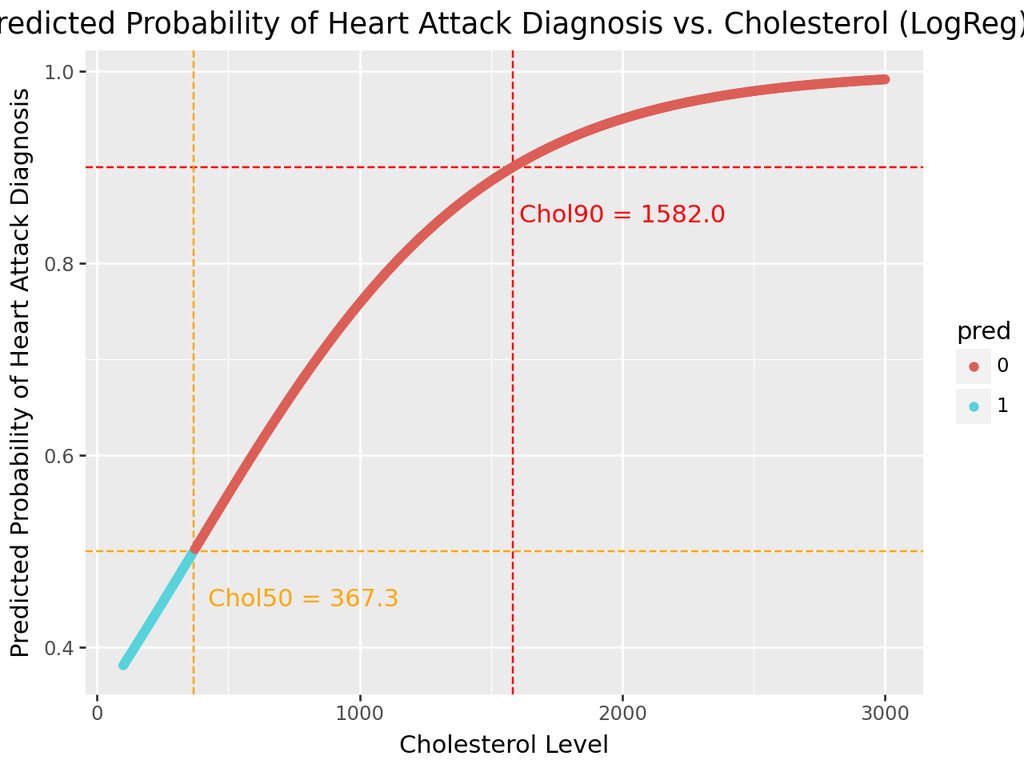

```python
from plotnine import ggplot, aes, geom_point, geom_hline, geom_vline, annotate, labs, geom_abline

chol_at_0_5 = chol_df.loc[chol_df['pred_prob'].sub(0.5).abs().idxmin(), 'chol']
chol_at_0_9 = chol_df.loc[chol_df['pred_prob'].sub(0.9).abs().idxmin(), 'chol']


(ggplot(chol_df, aes(x = "chol", y = "pred_prob", color = "pred"))+
    geom_hline(yintercept = 0.9, color = "red", linetype = "dashed")+
    geom_hline(yintercept = 0.5, color = "orange", linetype = "dashed")+
    geom_vline(xintercept=chol_at_0_5, color="orange", linetype="dashed") +
    geom_vline(xintercept=chol_at_0_9, color="red", linetype="dashed") +

    annotate("text", x = chol_at_0_5 + 420, y = 0.45, label = f"Chol50 = {chol_at_0_5:.1f}", color = "orange")+
    annotate("text", x = chol_at_0_9 + 420, y = 0.85, label=f"Chol90 = {chol_at_0_9:.1f}", color = "red")+

    geom_point()+
    labs(title = "Predicted Probability of Heart Attack Diagnosis vs. Cholesterol (LogReg)",
         x = "Cholesterol Level",
         y = "Predicted Probability of Heart Attack Diagnosis"))
```

## 2. Linear Discriminant Analysis

Fit an LDA model using only `age` and `chol` (cholesterol) as predictors.

For a 55 year old, how high would their cholesterol need to be for the doctors to predict heart disease is present?

```python
from sklearn.discriminant_analysis import LinearDiscriminantAnalysis

ct = ColumnTransformer(
  [
    ("dummify",
    OneHotEncoder(sparse_output=False, handle_unknown='ignore', drop='first'),
    make_column_selector(dtype_include=object)),
    ("standardize",
    StandardScaler(),
    make_column_selector(dtype_include=np.number))
  ],
  remainder = "passthrough"
).set_output(transform = "pandas")

lda_pipeline = Pipeline([
    ("preprocessing", ct),
    ("lda", LinearDiscriminantAnalysis())
])

lda_pipeline.fit(df[["age", "chol"]], df["diagnosis"])
```

```
Pipeline(steps=[('preprocessing',
                 ColumnTransformer(remainder='passthrough',
                                   transformers=[('dummify',
                                                  OneHotEncoder(drop='first',
                                                                handle_unknown='ignore',
                                                                sparse_output=False),
                                                  <sklearn.compose._column_transformer.make_column_selector object at 0x000001D018359310>),
                                                 ('standardize',
                                                  StandardScaler(),
                                                  <sklearn.compose._column_transformer.make_column_selector object at 0x000001D01717BAA0>)])),
                ('lda', LinearDiscriminantAnalysis())])
```

```python
coefficients = lda_pipeline.named_steps["lda"].coef_
print(coefficients)
```

[output not shown]

```python
age = [55] * 500
cholesterol_values = np.linspace(100, 3000, 500).tolist()

chol_df2 = pd.DataFrame({"age": age,
                        "chol": cholesterol_values})

chol_df2.head()
```

|  | age | chol |
| --- | --- | --- |
| 0 | 55 | 100.000000 |
| 1 | 55 | 105.811623 |
| 2 | 55 | 111.623246 |
| 3 | 55 | 117.434870 |
| 4 | 55 | 123.246493 |

```python
chol_df2["pred"] = lda_pipeline.predict(chol_df2)
chol_df2["pred_prob"] = lda_pipeline.predict_proba(chol_df2)[:, 0]
chol_df2['pred'] = chol_df2['pred'].astype('category')

chol_df2.head()
```

|  | age | chol | pred | pred_prob |
| --- | --- | --- | --- | --- |
| 0 | 55 | 100.000000 | 1 | 0.382240 |
| 1 | 55 | 105.811623 | 1 | 0.384699 |
| 2 | 55 | 111.623246 | 1 | 0.387164 |
| 3 | 55 | 117.434870 | 1 | 0.389634 |
| 4 | 55 | 123.246493 | 1 | 0.392111 |

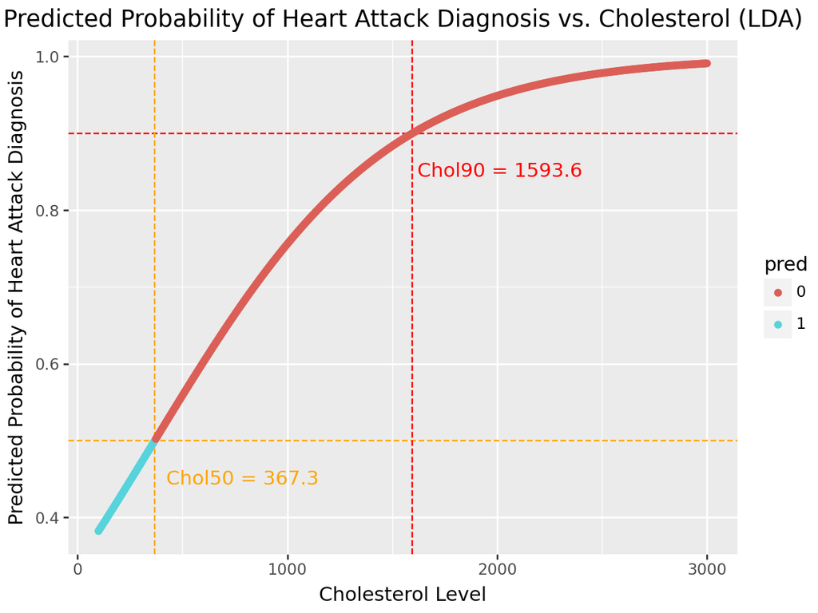

```python
chol_at_0_5 = chol_df2.loc[chol_df2['pred_prob'].sub(0.5).abs().idxmin(), 'chol']
chol_at_0_9 = chol_df2.loc[chol_df2['pred_prob'].sub(0.9).abs().idxmin(), 'chol']


(ggplot(chol_df2, aes(x = "chol", y = "pred_prob", color = "pred"))+
    geom_hline(yintercept = 0.9, color = "red", linetype = "dashed")+
    geom_hline(yintercept = 0.5, color = "orange", linetype = "dashed")+
    geom_vline(xintercept=chol_at_0_5, color="orange", linetype="dashed") +
    geom_vline(xintercept=chol_at_0_9, color="red", linetype="dashed") +

    annotate("text", x = chol_at_0_5 + 420, y = 0.45, label = f"Chol50 = {chol_at_0_5:.1f}", color = "orange")+
    annotate("text", x = chol_at_0_9 + 420, y = 0.85, label=f"Chol90 = {chol_at_0_9:.1f}", color = "red")+

    geom_point()+
    labs(title = "Predicted Probability of Heart Attack Diagnosis vs. Cholesterol (LDA)",
         x = "Cholesterol Level",
         y = "Predicted Probability of Heart Attack Diagnosis"))
```

## 3. Support Vector Classifier

Fit an SVC model using only `age` and `chol` as predictors. Don’t forget to tune the regularization parameter.

For a 55 year old, how high would their cholesterol need to be for the doctors to predict heart disease is present?

```python
from sklearn.svm import SVC

ct = ColumnTransformer(
  [
    ("dummify",
    OneHotEncoder(sparse_output=False, handle_unknown='ignore', drop='first'),
    make_column_selector(dtype_include=object)),
    ("standardize",
    StandardScaler(),
    make_column_selector(dtype_include=np.number))
  ],
  remainder = "passthrough"
).set_output(transform = "pandas")

svc_pipeline = Pipeline([
    ("preprocessing", ct),
    ("svc", SVC(probability=True))
])

param_grid = {"svc__C": [0.1, 1, 10, 100],
              'svc__kernel': ['linear']}

grid_search = GridSearchCV(svc_pipeline, param_grid, cv=5, scoring="accuracy")
grid_search.fit(df[["age", "chol"]], df["diagnosis"])

best_svc = grid_search.best_estimator_
print(f"Best C: {grid_search.best_params_['svc__C']}")
```

[output not shown]

```python
age = [55] * 500
cholesterol_values = np.linspace(100, 600, 500).tolist()

chol_df3 = pd.DataFrame({"age": age,
                        "chol": cholesterol_values})

chol_df3.head()
```

|  | age | chol |
| --- | --- | --- |
| 0 | 55 | 100.000000 |
| 1 | 55 | 101.002004 |
| 2 | 55 | 102.004008 |
| 3 | 55 | 103.006012 |
| 4 | 55 | 104.008016 |

```python
chol_df3["pred"] = best_svc.predict(chol_df3)
chol_df3["pred_prob"] = best_svc.decision_function(chol_df3)
chol_df3['pred'] = chol_df3['pred'].astype('category')

chol_df3.head()
```

|  | age | chol | pred | pred_prob |
| --- | --- | --- | --- | --- |
| 0 | 55 | 100.000000 | 1 | 0.778478 |
| 1 | 55 | 101.002004 | 1 | 0.774810 |
| 2 | 55 | 102.004008 | 1 | 0.771142 |
| 3 | 55 | 103.006012 | 1 | 0.767474 |
| 4 | 55 | 104.008016 | 1 | 0.763806 |

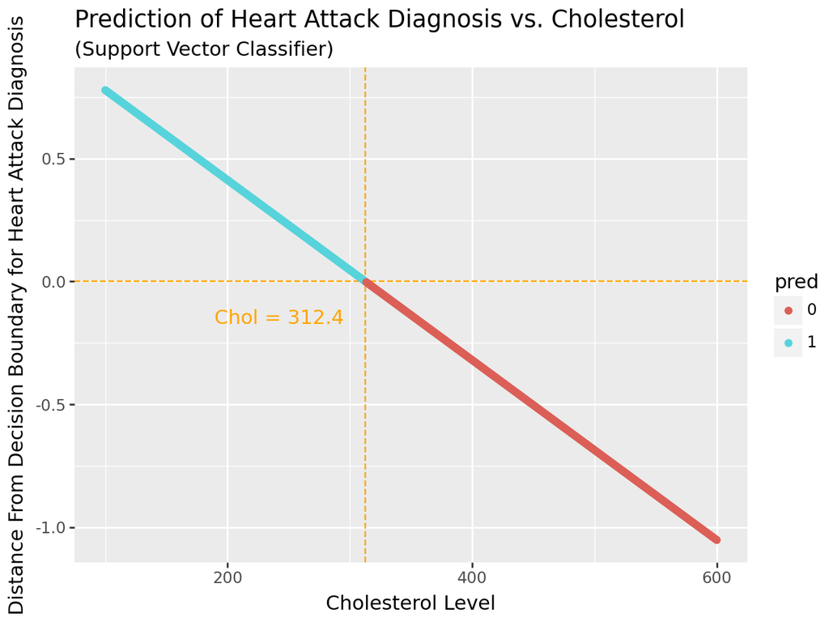

```python
chol_at_zero = chol_df3.loc[chol_df3['pred_prob'].sub(0).abs().idxmin(), 'chol']


(ggplot(chol_df3, aes(x="chol", y="pred_prob", color="pred")) +
    geom_hline(yintercept=0, color="orange", linetype="dashed") +
    geom_vline(xintercept=chol_at_zero, color="orange", linetype="dashed") +
    annotate("text", x=chol_at_zero - 70, y= -0.15,
             label=f"Chol = {chol_at_zero:.1f}", color="orange") +

    geom_point() +
    labs(title="Prediction of Heart Attack Diagnosis vs. Cholesterol",
         subtitle="(Support Vector Classifier)",
         x="Cholesterol Level",
         y="Distance From Decision Boundary for Heart Attack Diagnosis")
)
```

## 4. Comparing Decision Boundaries

Make a scatterplot of `age` and `chol`, coloring the points by their true disease outcome. Add a line to the plot representing the **linear separator** (aka **decision boundary**) for each of the three models above.

```python
# Logistic Regression Coefficients (LogReg)
logreg_coef = logreg_pipeline.named_steps['logreg'].coef_[0]
logreg_intercept = logreg_pipeline.named_steps['logreg'].intercept_[0]

# LDA Coefficients (LDA)
lda_coef = lda_pipeline.named_steps['lda'].coef_[0]
lda_intercept = lda_pipeline.named_steps['lda'].intercept_[0]

# SVC Coefficients (SVC with linear kernel)
svc_model = best_svc.named_steps['svc']
svc_coef = svc_model.coef_[0]
svc_intercept = svc_model.intercept_[0]
```

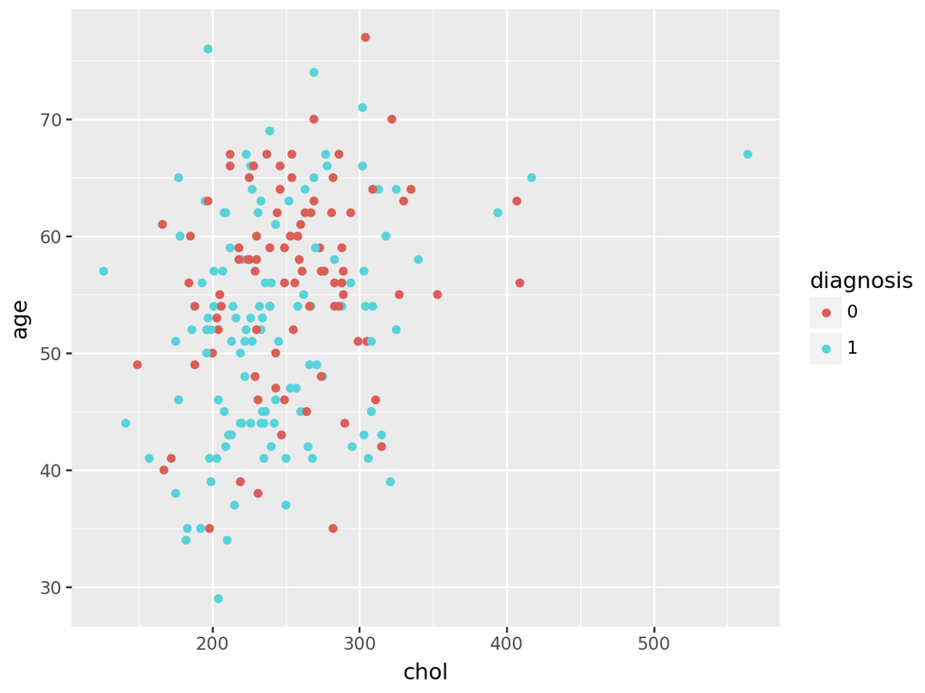

```python
df["diagnosis"] = df["diagnosis"].astype("category")

(ggplot(df, aes(x = "chol", y = "age", color = "diagnosis"))+
    geom_point())
```

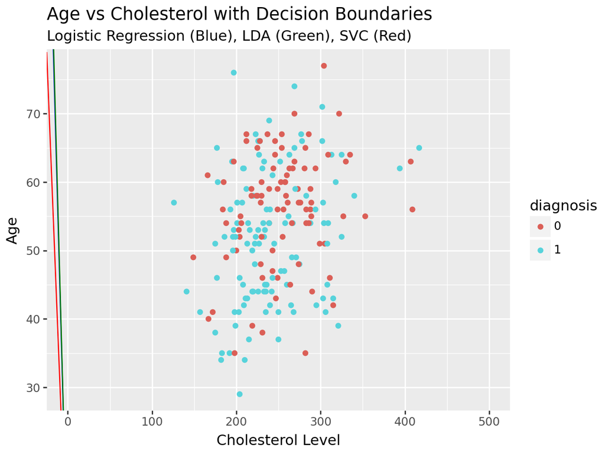

```python
from plotnine import ggplot, aes, geom_point, geom_abline, labs, scale_x_continuous
import numpy as np

# Logistic Regression Coefficients (LogReg)
logreg_coef = logreg_pipeline.named_steps['logreg'].coef_[0]
logreg_intercept = logreg_pipeline.named_steps['logreg'].intercept_[0]

# LDA Coefficients (LDA)
lda_coef = lda_pipeline.named_steps['lda'].coef_[0]
lda_intercept = lda_pipeline.named_steps['lda'].intercept_[0]

# SVC Coefficients (SVC with linear kernel)
svc_model = best_svc.named_steps['svc']
svc_coef = svc_model.coef_[0]
svc_intercept = svc_model.intercept_[0]

(ggplot(df, aes(x='chol', y='age', color='diagnosis')) +
        geom_point() +
        # Logistic Regression Decision Boundary (Blue)
        geom_abline(slope=-logreg_coef[0]/logreg_coef[1], intercept=-logreg_intercept/logreg_coef[1], color='blue', linetype='solid') +
        # LDA Decision Boundary (Green)
        geom_abline(slope=-lda_coef[0]/lda_coef[1], intercept=-lda_intercept/lda_coef[1], color='green', linetype='solid') +
        # SVC Decision Boundary (Red)
        geom_abline(slope=-svc_coef[0]/svc_coef[1], intercept=-svc_intercept/svc_coef[1], color='red', linetype='solid') +
        labs(title='Age vs Cholesterol with Decision Boundaries',
             subtitle='Logistic Regression (Blue), LDA (Green), SVC (Red)',
             x='Cholesterol Level', y='Age')+
        scale_x_continuous(limits=[0, 500]))
```